# HUDM 6122 Final Project

Getong Zhong

2023-05-11

# Introduction

The dataset was collected from the Global Health Observatory (GHO) data repository maintained by the World Health Organization (WHO). In this data set, the 20 predicting variables that influence life expectancy were categorized into distinct groups, including immunization-related factors, mortality factors, economic factors, and social factors. The dataset consists of merged individual data files, resulting in a comprehensive dataset with 22 columns and 2938 rows, representing 193 countries. Initial visual inspection revealed missing values, primarily in variables related to population, Hepatitis B, and GDP. Due to difficulties in obtaining data for certain less known countries like Vanuatu, Tonga, Togo, Cabo Verde, these countries were excluded from the final model dataset.

# Data Cleannig

```r
life <- read.csv("life.csv")

# Standardize data

# In this Project, we only include data for Year 2015 for multivariate analysis
life <- filter(life, Year == 2015)
# Since column Alcohol, Total.expenditure, contains too many NA, and column percentage.expenditure and Income.composition.of.resources contain too many 0 values, therefore we are going to drop these columns.
life <- life[,c(-7,-8,-14)]
life <- life[,c(-1,-2, -3)]
# For other NAs, we are going to fill it with the mean value of that column
life$Hepatitis.B <- as.numeric(life$Hepatitis.B)
life2 <- life %>% mutate(across(everything(), ~ replace_na(., mean(., na.rm = TRUE))))
summary(life2)
```

```
##  Life.expectancy Adult.Mortality infant.deaths    Hepatitis.B
##  Min.   :51.00   Min.   :  1.0   Min.   :  0.0   Min.   : 6.00
##  1st Qu.:65.75   1st Qu.: 74.0   1st Qu.:  0.0   1st Qu.:81.00
##  Median :73.90   Median :138.0   Median :  2.0   Median :92.00
##  Mean   :71.62   Mean   :152.9   Mean   : 23.8   Mean   :82.43
##  3rd Qu.:76.95   3rd Qu.:213.0   3rd Qu.: 17.0   3rd Qu.:97.00
##  Max.   :88.00   Max.   :484.0   Max.   :910.0   Max.   :99.00
##     Measles           BMI        under.five.deaths     Polio
##  Min.   :    0   Min.   : 2.50   Min.   :   0.00   Min.   : 5.00
##  1st Qu.:    0   1st Qu.:24.30   1st Qu.:   0.00   1st Qu.:83.00
##  Median :   17   Median :48.60   Median :   3.00   Median :93.00
##  Mean   : 1503   Mean   :42.75   Mean   :  31.61   Mean   :83.21
##  3rd Qu.:  202   3rd Qu.:61.35   3rd Qu.:  21.00   3rd Qu.:97.00
##  Max.   :90387   Max.   :77.60   Max.   :1100.00   Max.   :99.00
##    Diphtheria       HIV.AIDS           GDP             Population
##  Min.   : 6.00   Min.   :0.1000   Min.   :   33.68   Min.   :     2966
##  1st Qu.:83.50   1st Qu.:0.1000   1st Qu.: 1152.31   1st Qu.:   604820
##  Median :93.00   Median :0.1000   Median : 4132.76   Median :  5511977
##  Mean   :84.63   Mean   :0.6607   Mean   : 7185.33   Mean   : 11097408
##  3rd Qu.:97.00   3rd Qu.:0.4000   3rd Qu.: 7185.33   3rd Qu.: 11097408
##  Max.   :99.00   Max.   :9.3000   Max.   :66346.52   Max.   :258162113
##  thinness..1.19.years thinness.5.9.years Income.composition.of.resources
##  Min.   : 0.100       Min.   : 0.100     Min.   :0.3470
##  1st Qu.: 1.500       1st Qu.: 1.500     1st Qu.:0.5755
##  Median : 3.500       Median : 3.400     Median :0.7180
##  Mean   : 4.535       Mean   : 4.576     Mean   :0.6917
##  3rd Qu.: 6.500       3rd Qu.: 6.400     3rd Qu.:0.7945
##  Max.   :26.700       Max.   :27.300     Max.   :0.9480
##    Schooling
##  Min.   : 4.90
##  1st Qu.:11.10
##  Median :12.93
##  Mean   :12.93
##  3rd Qu.:14.85
##  Max.   :20.40
```

# Multiple Linear Regression

## Relationship between Variables

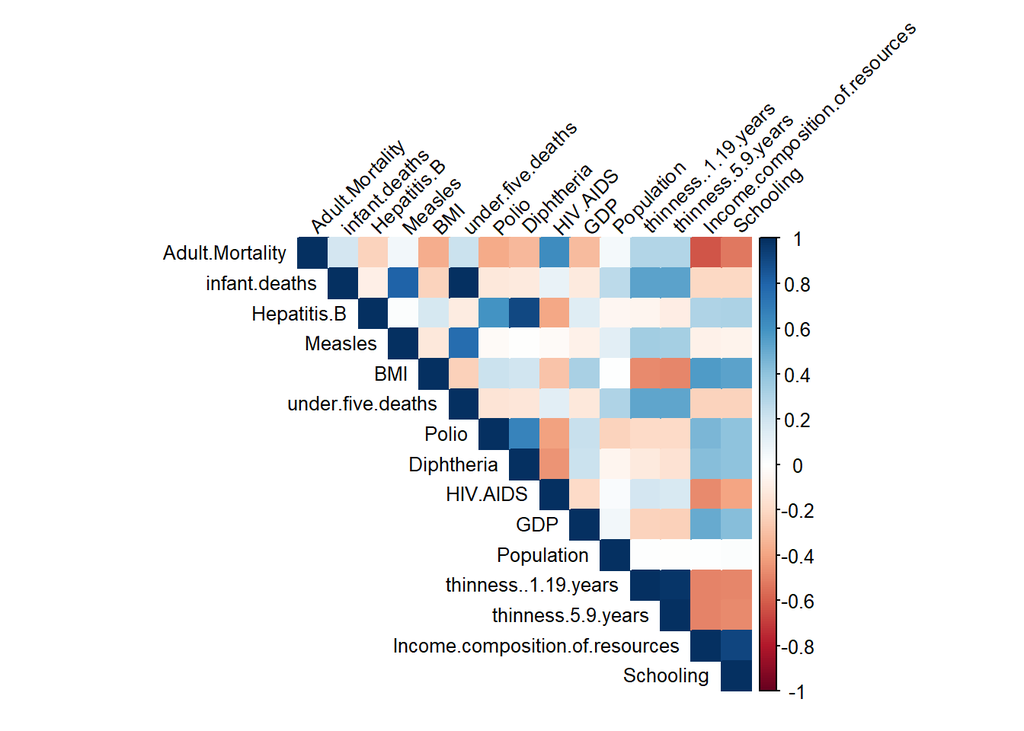

```r
library(corrplot)
# Create scatterplot matrix
cor_matrix <- cor(life2[,-1])
corrplot(cor_matrix, method = "color", type = "upper",
         tl.col = "black", tl.srt = 45,
         tl.cex = 0.8, cl.cex = 0.8)
```

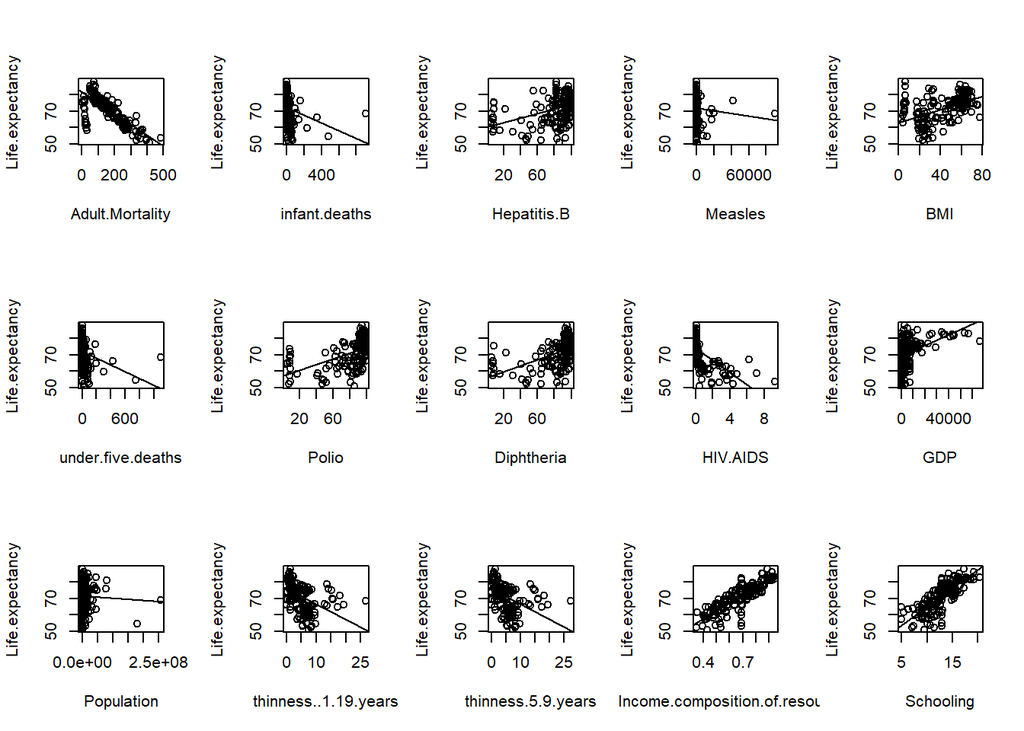

```r
par(mfrow = c(3, 5))

# Loop through each variable and create scatter plots
for (i in 2:16) {
  plot( life2[, i], life2$Life.expectancy, xlab = names(life2)[i], ylab = "Life.expectancy")
  abline(lm(life2$Life.expectancy ~ life2[, i]))
}
```

## Initial Linear Model for Life Expectancy

```r
MLR <- lm(Life.expectancy ~ ., data = life2)
summary(MLR)
```

```
##
## Call:
## lm(formula = Life.expectancy ~ ., data = life2)
##
## Residuals:
##      Min       1Q   Median       3Q      Max
## -10.5242  -1.4107   0.0229   1.4727   7.8180
##
## Coefficients:
##                                   Estimate Std. Error t value Pr(>|t|)
## (Intercept)                      5.434e+01  2.168e+00  25.062  < 2e-16 ***
## Adult.Mortality                 -2.805e-02  3.505e-03  -8.003 1.95e-13 ***
## infant.deaths                    8.845e-02  3.536e-02   2.501   0.0133 *
## Hepatitis.B                      2.360e-02  2.445e-02   0.965   0.3358
## Measles                         -3.711e-05  5.791e-05  -0.641   0.5225
## BMI                              3.500e-04  1.444e-02   0.024   0.9807
## under.five.deaths               -6.723e-02  2.573e-02  -2.613   0.0098 **
## Polio                            1.426e-02  1.381e-02   1.033   0.3032
## Diphtheria                       1.307e-02  2.844e-02   0.460   0.6464
## HIV.AIDS                        -4.075e-01  2.369e-01  -1.720   0.0873 .
## GDP                              5.491e-06  2.503e-05   0.219   0.8266
## Population                       5.160e-09  1.066e-08   0.484   0.6291
## thinness..1.19.years            -2.116e-01  2.587e-01  -0.818   0.4146
## thinness.5.9.years               5.273e-03  2.552e-01   0.021   0.9835
## Income.composition.of.resources  2.537e+01  4.764e+00   5.326 3.21e-07 ***
## Schooling                        7.311e-02  2.111e-01   0.346   0.7296
## ---
## Signif. codes:  0 '***' 0.001 '**' 0.01 '*' 0.05 '.' 0.1 ' ' 1
##
## Residual standard error: 3.079 on 167 degrees of freedom
## Multiple R-squared:  0.8682, Adjusted R-squared:  0.8564
## F-statistic: 73.33 on 15 and 167 DF,  p-value: < 2.2e-16
```

## Principal Component Analysis

The results of the Principal Component Analysis (PCA) provide valuable insights into the underlying structure and variability of the data. The PCA output reveals that the first few principal components (PCs) carry significant importance in explaining the variability in the dataset. PC1 exhibits the highest standard deviation (2.3227) and accounts for a substantial proportion of the variance (35.97%). This indicates that PC1 captures the primary patterns and trends in the data. As we consider subsequent PCs, the standard deviation and proportion of variance decrease, implying that these components explain progressively smaller portions of the overall variability. However, it is important to note that the cumulative proportion of variance increases as we move along the PCs, demonstrating that the combined effect of multiple components provides a comprehensive understanding of the data. The cumulative proportion reaches 92.62% by PC8, indicating that these eight components explain a significant majority of the total variance. These results suggest that the dataset exhibits inherent structure that can be effectively summarized using a reduced set of principal components.

```r
set.seed(123)
pca <- prcomp(life2[,2:ncol(life2)], scale. = TRUE)
summary(pca)
```

```
## Importance of components:
##                           PC1    PC2    PC3     PC4     PC5     PC6     PC7
## Standard deviation     2.3227 1.6897 1.3411 1.01171 0.93564 0.92215 0.75988
## Proportion of Variance 0.3597 0.1903 0.1199 0.06824 0.05836 0.05669 0.03849
## Cumulative Proportion  0.3597 0.5500 0.6699 0.73814 0.79651 0.85320 0.89169
##                            PC8     PC9    PC10    PC11    PC12    PC13    PC14
## Standard deviation     0.71985 0.62993 0.56874 0.46336 0.28611 0.25016 0.15443
## Proportion of Variance 0.03455 0.02645 0.02156 0.01431 0.00546 0.00417 0.00159
## Cumulative Proportion  0.92624 0.95269 0.97426 0.98857 0.99403 0.99820 0.99979
##                           PC15
## Standard deviation     0.05630
## Proportion of Variance 0.00021
## Cumulative Proportion  1.00000
```

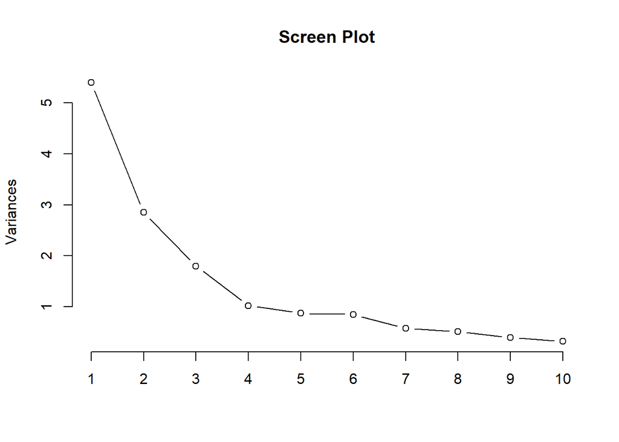

```r
plot(pca, type = "lines", main = "Screen Plot")
```

## Factor Analysis

```r
fa <- factanal(life2[,2:ncol(life2)], factors = 1, method = "mle")

fa
```

```
##
## Call:
## factanal(x = life2[, 2:ncol(life2)], factors = 1, method = "mle")
##
## Uniquenesses:
##                 Adult.Mortality                   infant.deaths
##                           0.600                           0.937
##                     Hepatitis.B                         Measles
##                           0.881                           0.989
##                             BMI               under.five.deaths
##                           0.653                           0.926
##                           Polio                      Diphtheria
##                           0.770                           0.792
##                        HIV.AIDS                             GDP
##                           0.760                           0.754
##                      Population            thinness..1.19.years
##                           1.000                           0.715
##              thinness.5.9.years Income.composition.of.resources
##                           0.715                           0.049
##                       Schooling
##                           0.137
##
## Loadings:
##                                 Factor1
## Adult.Mortality                 -0.632
## infant.deaths                   -0.251
## Hepatitis.B                      0.344
## Measles                         -0.106
## BMI                              0.589
## under.five.deaths               -0.272
## Polio                            0.479
## Diphtheria                       0.456
## HIV.AIDS                        -0.490
## GDP                              0.496
## Population
## thinness..1.19.years            -0.534
## thinness.5.9.years              -0.533
## Income.composition.of.resources  0.975
## Schooling                        0.929
##
##                Factor1
## SS loadings      4.320
## Proportion Var   0.288
##
## Test of the hypothesis that 1 factor is sufficient.
## The chi square statistic is 2102.48 on 90 degrees of freedom.
## The p-value is 0
```

```r
summary(fa)
```

```
##              Length Class    Mode
## converged      1    -none-   logical
## loadings      15    loadings numeric
## uniquenesses  15    -none-   numeric
## correlation  225    -none-   numeric
## criteria       3    -none-   numeric
## factors        1    -none-   numeric
## dof            1    -none-   numeric
## method         1    -none-   character
## STATISTIC      1    -none-   numeric
## PVAL           1    -none-   numeric
## n.obs          1    -none-   numeric
## call           4    -none-   call
```

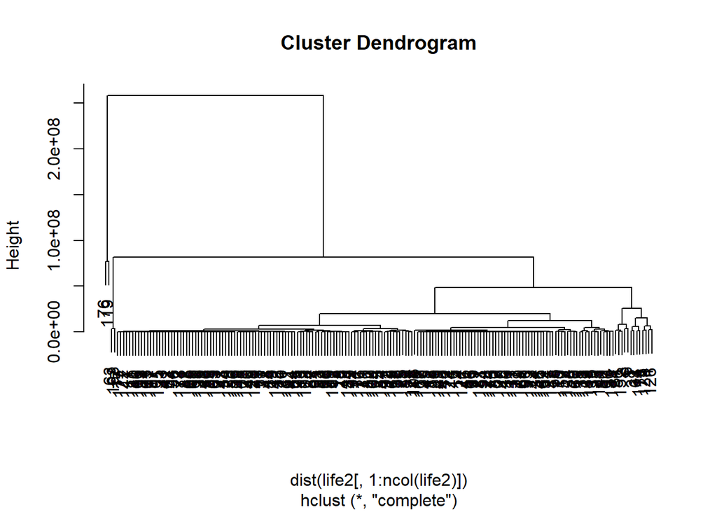

```r
# Perform CA
ca <- hclust(dist(life2[,1:ncol(life2)]))
plot(ca)
```